# Female academic trajectories (1967-2015)

Joanna Tang, Sandro Lallas, Rachem Behm

11/27/2018

# INTRODUCTION

# METHODS

## Data Collection

## Statistical Analyses

All statistical analyses and figures were created in R (version 3.4.2). Data for graduate enrollment (1967-2015) were fitted to linear regression models to analyze changes in graduate enrollment over time. Chi-squared tests were performed to analyze shifts in female PhD recipients by field (1985, 2000, and 2015). Since our data for post-graduate starting salaries were not normally distributed, we used Wilcoxon signed-rank tests to analyze significant differences between male and female salaries for starting postdoctoral and other employment positions (2015). Data for faculty salaries were fitted to multiple linear regression models to analyze the effects of faculty sex, rank, years in current position, discipline, and number of years since doctoral degree was earned on faculty salaries.

# RESULTS

## Male and female graduate enrollment (1967-2015)

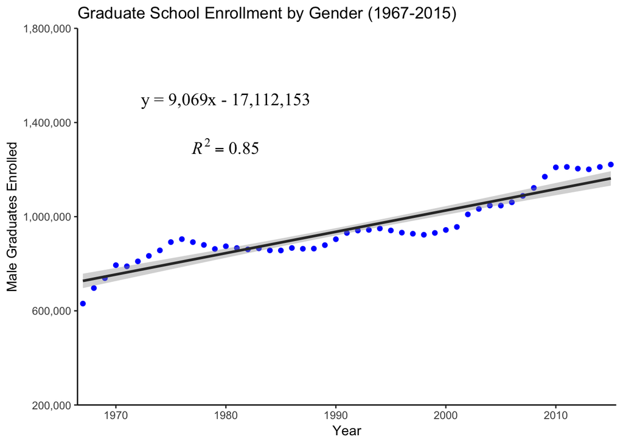

[figure not shown]

Total graduate enrollment of both males and females increased from 1967 to 2015 (Fig. 1). Male enrollment increased from 630,701 in 1967 to 1,221,566 in 2015. Female enrollment increased from 265,364 in 1967 to 1,718,926 in 2015. Most notably, up until 1988, total male enrollment exceeded total female enrollment; since 1988, total female enrollment has exceeded total male enrollment. The year significantly predicts male graduate enrollment (Pearson’s *r* = .92). The overall model (Male enrollment = 9,069 x Year - 17,112,153) explains a significant amount of variance in male graduate enrollment (F(1, 47) = 276, *p* < 0.001, R<sup>2</sup> = 0.85). The year significantly predicts female graduate enrollment (Pearson’s *r* = .99). The overall model (Female enrollment = 30,126 x Year - 58,955,502) explains a significant amount of variance in female graduate enrollment (F(1, 47) = 2,669, *p* < 0.001, R<sup>2</sup> = 0.98).

## Shifts in female PhD recipients

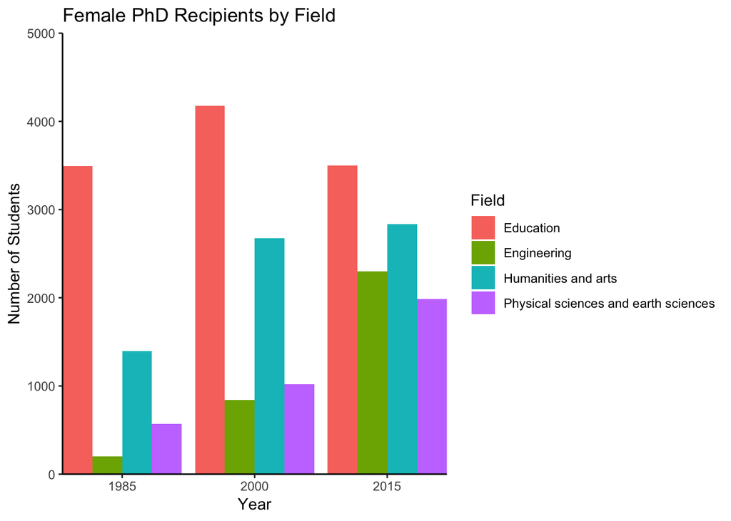

```
##                                 1985       2000      2015
## Education                 0.61787611 0.47973826 0.3296621
## Engineering               0.03504425 0.09620021 0.2166055
## Humanities & Arts         0.24637168 0.30673861 0.2665914
## Physical & Earth Sciences 0.10070796 0.11732293 0.1871411
```

Female PhD Contingency Matrix

|  | 1985 | 2000 | 2015 |
| --- | --- | --- | --- |
| Education | 0.6178761 | 0.4797383 | 0.3296621 |
| Engineering | 0.0350442 | 0.0962002 | 0.2166055 |
| Humanities & Arts | 0.2463717 | 0.3067386 | 0.2665914 |
| Physical & Earth Sciences | 0.1007080 | 0.1173229 | 0.1871411 |

The number of female PhD recipients in Education increased from 3,491 in 1985 to 4,179 in 2000, but then decreased to 3,502 in 2015 (Fig. 2). This is the only field for which the number of recipients declined from 2000 to 2015.

The number of female PhD recipients in Engineering increased from 198 in 1985, to 838 in 2000, to 2,301 in 2015 (Fig. 2).

The number of female PhD recipients in Humanities & Arts increased from 1,392 in 1985, to 2,672 in 2000, to 2,832 in 2015 (Fig. 2).

The number of female PhD recipients in Physical & Earth Sciences increased from 569 in 1985, to 1,022 in 2000, to 1,988 in 2015 (Fig. 2).

There is a significant effect of year on the proportion of PhD recipients in each field ($\chi^2$(6) = 2073.3, *p* < 0.001).

## Male and female salaries for starting postdoctoral and other employment positions (2015)

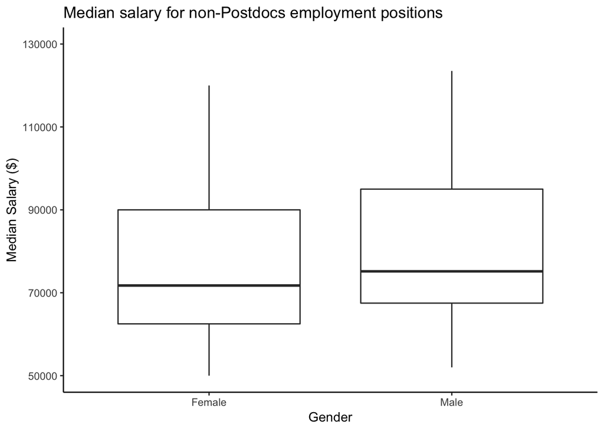

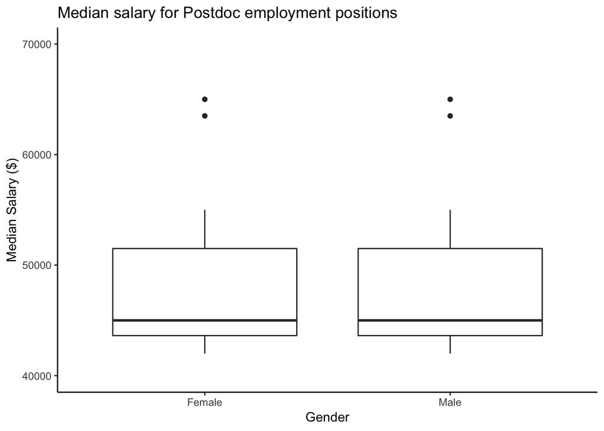

The median starting non-postdoc employment positions differ significantly for males (median = 75,167 males) and females (median = 71,750 females) in our samples (V = 101, *p* = 0.0026, $\alpha$ = .05, Cliff’s delta = .21) (Fig. 3). Thus, median salary does differ significantly between male and female starting non-postdoc employment position salaries.

## Academic salaries for professors in U.S. colleges

|  | *Dependent variable:* |  |  |
| --- | --- | --- | --- |
|  | Salary |  |  |
|  | (1) | (2) | (3) |
| SexMale | 4,783.493 | 4,349.366 | 4,491.801 |
|  | (3,858.668) | (3,875.393) | (3,860.240) |
| RankAssocProf | 12,907.590*** | 13,104.150*** | 13,723.420*** |
|  | (4,145.278) | (4,167.315) | (3,959.014) |
| RankProf | 45,066.000*** | 46,032.550*** | 47,403.320*** |
|  | (4,237.523) | (4,240.120) | (3,133.108) |
| Years | -489.516** |  |  |
|  | (211.938) |  |  |
| DisciplineB | 14,417.630*** | 13,937.470*** | 13,708.690*** |
|  | (2,342.875) | (2,346.534) | (2,295.437) |
| Years_since | 535.058** | 61.011 |  |
|  | (240.994) | (127.010) |  |
| Constant | 65,955.230*** | 67,884.320*** | 68,223.530*** |
|  | (4,588.601) | (4,536.892) | (4,477.200) |
| Observations | 397 | 397 | 397 |
| R<sup>2</sup> | 0.455 | 0.447 | 0.447 |
| Adjusted R<sup>2</sup> | 0.446 | 0.440 | 0.441 |
| Residual Std. Error | 22,538.650 (df = 390) | 22,663.240 (df = 391) | 22,640.990 (df = 392) |
| F Statistic | 54.195*** (df = 6; 390) | 63.266*** (df = 5; 391) | 79.180*** (df = 4; 392) |
| *Note:* | p<0.1; p<0.05; p<0.01 |  |  |

# DISCUSSION

## Academic salaries for US professors (2008-2009)

# CONCLUSION

# REFERENCES